# Reporting Results

Stat 365: Statistical Communication

## Monday, May 8th

Today we will…

- Care with statistical terminology
- Statistical tendencies
- “Pesky” p-values
- “Significance”

## Statistical terms in everyday usage

Discuss what each of the following terms means in everyday usage.

- Error
- Variance
- Confidence
- Significance (we will talk more about this!)
- Independent

# Similar words, distinct meanings

## Fewer and Less

Use *fewer* when comparing quantities that can be counted.

- “Years when there are fewer inches of rainfall, there is a less dense snow pack”

Use *less* to compare quantities that cannot be counted.

- “Years when there is less rainfall, there is less dense snow pack.”

## Affect and Effect

Use *affect* as a verb that influences a noun.

- “What age group is most affected by sleep deprivation?”

Use *effect* as a noun that refers to a result or change (we do not necessarily attribute this to causation).

- “We compare the effect size of income on health across age groups”

## Causation

One way to check whether a sentence makes a causal statement is to flip the statement around.

“Watching more than 4 hours of TV a day brings about lower math scores.”

“Scoring poorly on math tests brings about excessive TV watching.”

## Statistical Tendencies

*I get up before 7am.*

- Suggest how you could add just two words to this statement, in order to make its meaning more clear.
- Give an example of a statistical tendency from your own life, not related to wake time, beginning with “I tend to …”
- Give an example of a statement that is true in every instance, not a statistical tendency.

## Recall the Mandela Study

Complete the statistical tendencies section on the handout

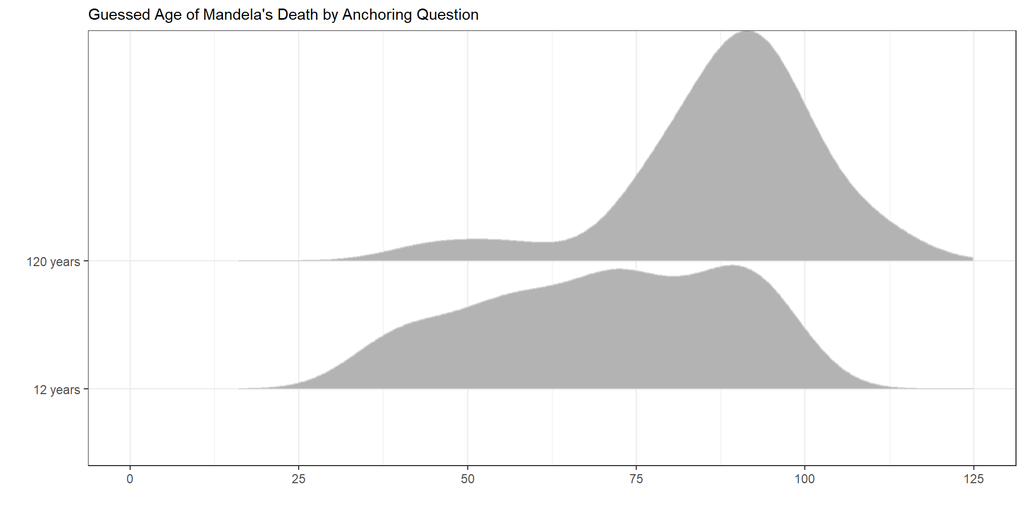

## “Pesky” p-values

Below is a graph of simulated values (120 years - 12 years) from the Rossman Chance two-sample mean applet.

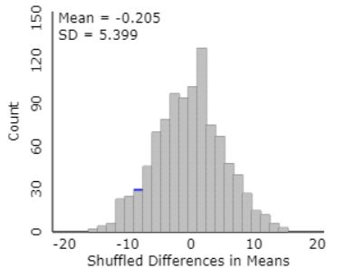

Below are results from a two-sample t-test assuming equal variances.

```
    Two Sample t-test

data:  guess_yrs by anchor_q
t = 3.6733, df = 45, p-value = 0.000317
alternative hypothesis: true difference in means between group 120 years and group 12 years is greater than 0
95 percent confidence interval:
 9.551312      Inf
sample estimates:
mean in group 120 years  mean in group 12 years
               87.96000                70.36364
```

## Statistical Significance vs Practical Importance

*Statistical significance* is determined by p-values, which measure the probability of observing a result as extreme as the one obtained in a study, assuming that the null hypothesis is true.

*Practical importance*, however, is determined by a combination of factors such as effect size, magnitude of difference, and relevance to real-world outcomes.

## It’s time to say farewell to “statistically significant”<sup>1</sup>

[Moving to a World Beyond “p<0.05”](https://amstat.tandfonline.com/doi/full/10.1080/00031305.2019.1583913#.ZFhy9nbMKF4)

[Scientists rise up against statistical significance](https://www.nature.com/articles/d41586-019-00857-9)

[^1]: via Ron Wasserstein CSP 2021 Presentation

## And what to do instead…

1. Lead with (focus on) effect sizes and related measures of uncertainty (for instance, interval estimates)

## And what to do instead…

2. Focus on the substantive implications of those estimates. (For example, don’t focus on whether the interval contains zero, but on whether the interval bounds have qualitatively different practical consequences.)

## And what to do instead…

3. When presenting p-values, present them as continuous values (not categorized into significant or not), and along with the standard p-value (null hypothesis), report p-values for other pre-specified hypotheses. (One example: instead of assuming no effect, assume the minimum meaningful effect size.)

## And what to do instead…

4. Interpret p-values as (uncertain) descriptive measures of compatibility with the model, and recognize that the value of p is impacted not just by the assumption of the null hypothesis, but by the many other assumptions/choices data analysts make

## And what to do instead…

5. Encourage researchers not to focus on the statistical measure alone (for example, the p-value) but also to consider
- related prior evidence
- plausibility of mechanism
- study design and data quality
- real world costs and benefits
- novelty of finding
- other factors that vary by research domain

(per McShane et al)

## To do

**Copy the Masters: Pick your Graphic**

- due Thursday, 5/11 at 11:59pm